# Analysis Inhaler

Author

Joana

Published

April 28, 2026

Research question:

Does a new inhaled corticosteroid (ICS-X) perform better in a randomized control trial over 6 weeks in patients with mild persistent asthma compared to a standard inhaler?

## 1 Prepare session

In this step the Quarto project has been prepared for the analysis of the data set lung function which contains 180 data points of distinct patients. The data set displays information about the age, FEV-1 improvement, baseline FEV-1, treatment group and smoking status.

## 2 Explore the data

To look at the different inhalation methods, the dataset is analyzed numerically and graphically.

### 2.1 Numerically

For the numerical exploration of the data, first the tabel Table 1 has been created, with which the descriptive statistics can be looked at.

Table 1: Descriptive statistics table of the variables of interest.

|  | fev1_improvement | age | baseline_fev1 | treatment_group |
| --- | --- | --- | --- | --- |
| nbr.val | 180.0 | 180.0 | 180.0 | NA |
| nbr.null | 32.0 | 0.0 | 0.0 | NA |
| nbr.na | 0.0 | 0.0 | 0.0 | NA |
| min | -0.5 | 32.0 | 0.8 | NA |
| max | 0.9 | 57.0 | 4.0 | NA |
| range | 1.4 | 25.0 | 3.2 | NA |
| sum | 17.4 | 8113.0 | 449.9 | NA |
| median | 0.1 | 45.5 | 2.5 | NA |
| mean | 0.1 | 45.1 | 2.5 | NA |
| SE.mean | 0.0 | 0.5 | 0.0 | NA |
| CI.mean.0.95 | 0.0 | 1.1 | 0.1 | NA |
| var | 0.1 | 53.0 | 0.4 | NA |
| std.dev | 0.2 | 7.3 | 0.6 | NA |
| coef.var | 2.4 | 0.2 | 0.2 | NA |
| skewness | 0.2 | -0.1 | -0.2 | NA |
| skew.2SE | 0.5 | -0.3 | -0.6 | NA |
| kurtosis | 0.3 | -1.3 | -0.2 | NA |
| kurt.2SE | 0.5 | -1.8 | -0.3 | NA |
| normtest.W | 1.0 | 0.9 | 1.0 | NA |
| normtest.p | 0.0 | 0.0 | 0.3 | NA |

To get information about the proportion in which the various treatments have been used, the tabel Table 2 has been created.

Table 2: This table displays information about the proportion of the treatment groups.

```
            ICSX standard_inhaler
              90               90
```

Another important factor in the analysis is the smoking status. The Table 3 serves to further elaborate the smoking status of the participants.

Table 3: This table displays information about the proportion of the participants which smoke.

```
current  former   never
     38      54      88
```

### 2.2 Graphically

To get a further impression of the data, it can be displayed graphically. The first step is to compare the treatment groups with Figure 1.

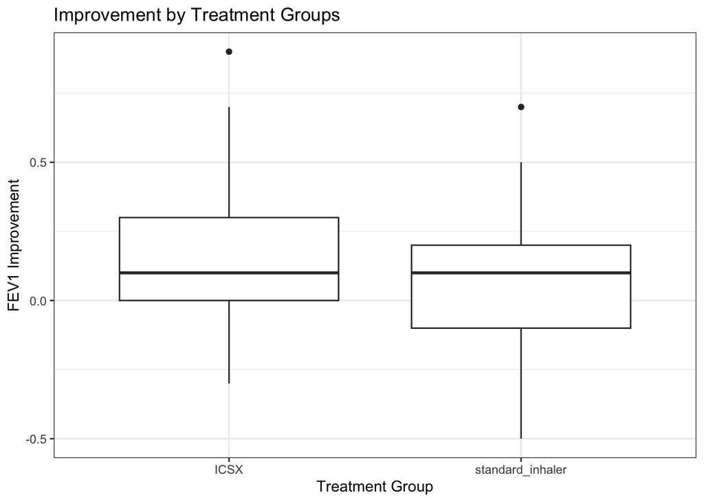

Figure 1: This figure shows the outcome between the treatment groups.

With the second Figure 2, the distribution of the FEV1 improvement can be explored.

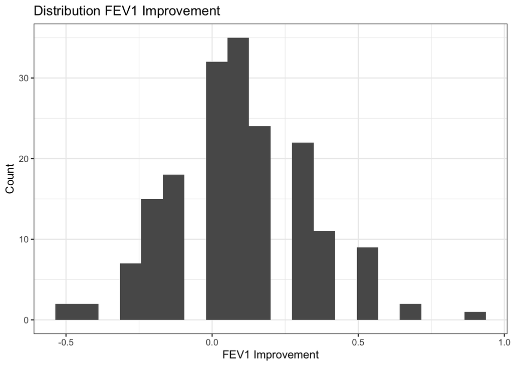

Figure 2: This figure shows how the FEV1 improvement is distributed.

## 3 Fit models

After the initial graphical and numerical exploration of the data, the models have been fit (Table 4). As we have a continous outcome variable (FEV1 improvement), the data is fitted with a linear model.

### 3.1 Formulate and compare

Table 4: Model comparison.

```r
# fit models
m0 <- lm(fev1_improvement ~ 1, lung)
m1 <- lm(fev1_improvement ~ treatment_group, lung)
m2 <- lm(fev1_improvement ~ treatment_group + age + baseline_fev1, lung)
m3 <- lm(fev1_improvement ~ treatment_group + age + baseline_fev1 + smoking_status, lung)

# compare models
kable(compare_performance(m0, m1, m2, m3), digits= 3)
```

[output not shown]

After fitting and comparing the models, m3 has been chosen to continue as it has the lowest AIC and BIC and the highest adjusted R^2. M3 has an adjusted R^2 has a 0.47.

### 3.2 Validate the preferred model

Before the chosen model can be interpreted, it has to be validated. To do so, the Figure 3 has been created. Model 3 works well to continue with.

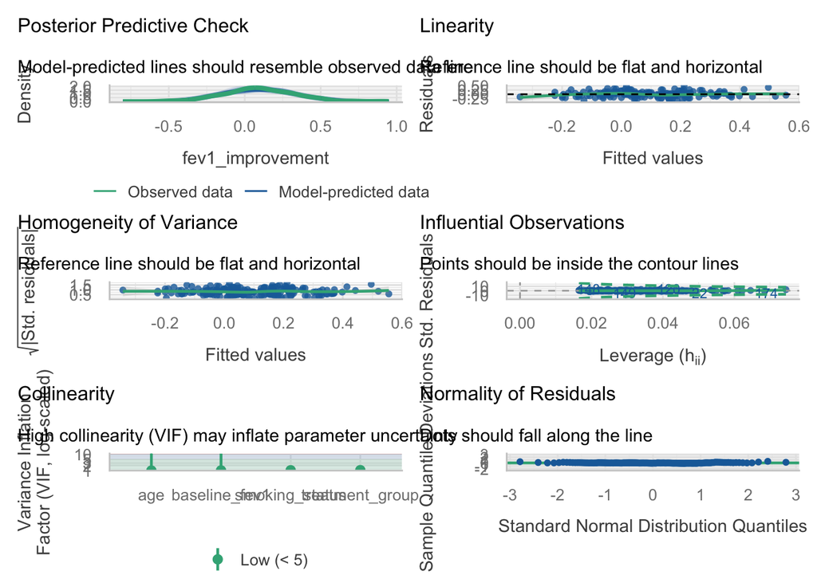

Figure 3: This figures show the diagonstic plots for the preferred linear model (m3).

```r
check_model(m3)
```

## 4 Interpret model

As m3 has been chosen and validated, the data interpretation can continue with it.

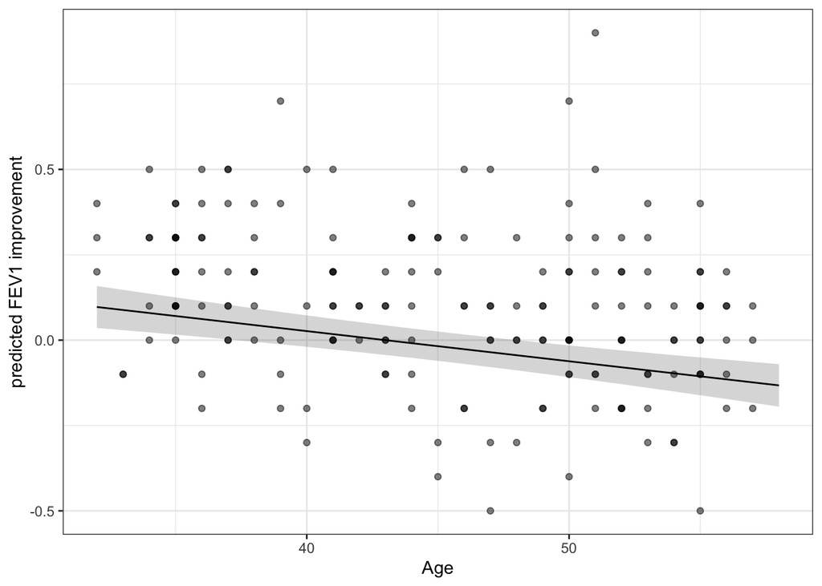

Figure 4: Predicted FEV1 improvement at different ages.

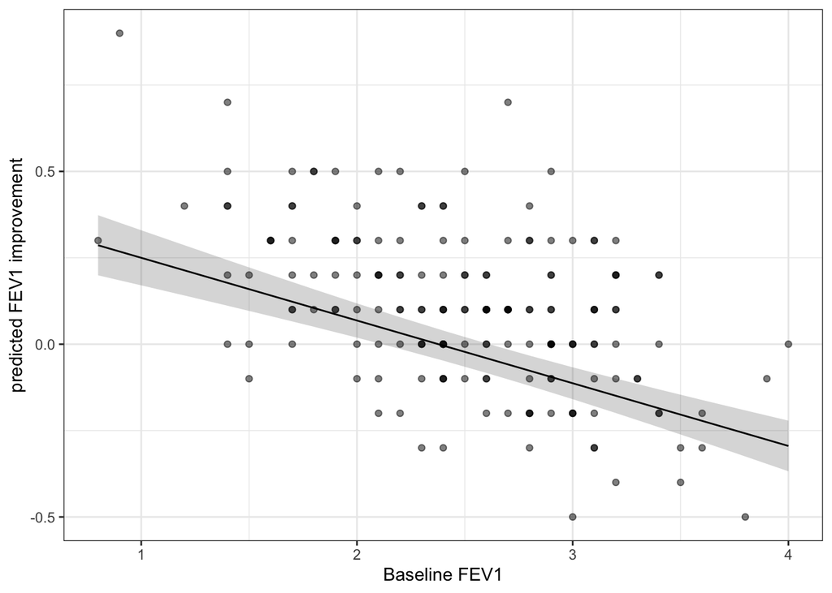

Figure 5: Predicted improvement with FEV1 across the baseline.

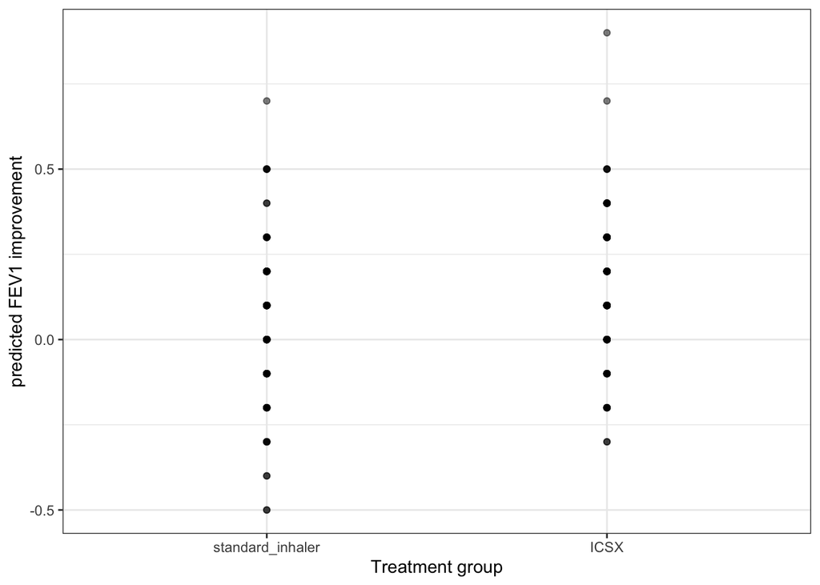

Figure 6: Predicted improvement with FEV1 in the different treatment groups.

Table 5: Linear model results for the preferred model. Adjusted R² = 0.47 , AIC = -121.38 .

|  | Estimate | Std. Error | t value | Pr(>\|t\|) |
| --- | --- | --- | --- | --- |
| (Intercept) | 1.110 | 0.097 | 11.467 | 0.000 |
| treatment_groupstandard_inhaler | -0.063 | 0.026 | -2.438 | 0.016 |
| age | -0.009 | 0.002 | -5.082 | 0.000 |
| baseline_fev1 | -0.182 | 0.021 | -8.469 | 0.000 |
| smoking_statusformer | -0.085 | 0.037 | -2.323 | 0.021 |
| smoking_statusnever | -0.213 | 0.033 | -6.468 | 0.000 |

## 5 Conclusion

The linear model (m3) which has been chosen explains 47% of the variability in the FEV1 improvement. Overall the patients with the standard treatment showed significantly lower (-0.063, p = 0.016) improvement. This leads to the conclusion the ICSX helps improving the lung function. Looking at the FEV1 improvement at different ages showed that it’s reduced with higher age (-0.009, p < 0.001). Higher baseline of FEV1 led also to a less good improvement (-0.182, p < 0.001). This could be because there is less room for improvement. Looking if the participants smoke or not also led to an interesting conclusion. Former smokers and participants who never smoked had a lower FEV1 improvement compared to smokers. The strongest reduction reduction have never smokers (-0.213, p < 0.001).